# IEU GWAS QC Report

## IEU GWAS information

Trait: **Urate**.

[output not shown]

## Report information

| name | value |
| --- | --- |
| gwas_id | ukb-d-30880_irnt |
| bcf_file | ukb-d-30880_irnt.vcf.gz |
| qc_metrics_file | qc_metrics.json |
| metadata | metadata.json |
| refdata | 1kg_v3_nomult.bcf |
| compile_time | 2020-05-10 12:00 BST |
| build_version | run_igd-8f4f4c9-2020-05-09 |

# Summary

## Summary {data-width=650}

### Manhattan plot

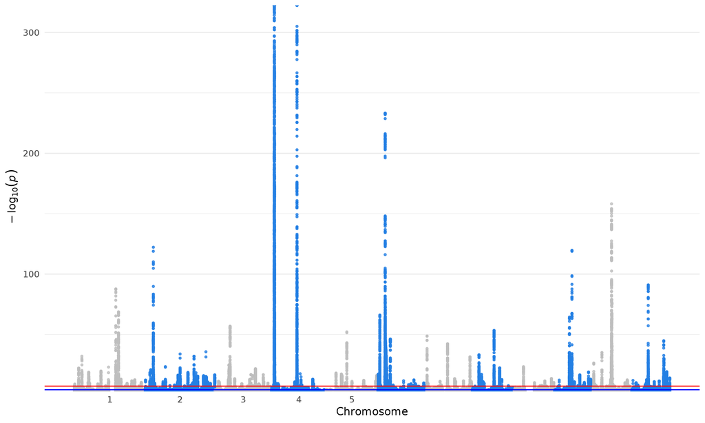

manhattan_plot

### QQ plot

[figure not shown]

qq_plot

### AF plot

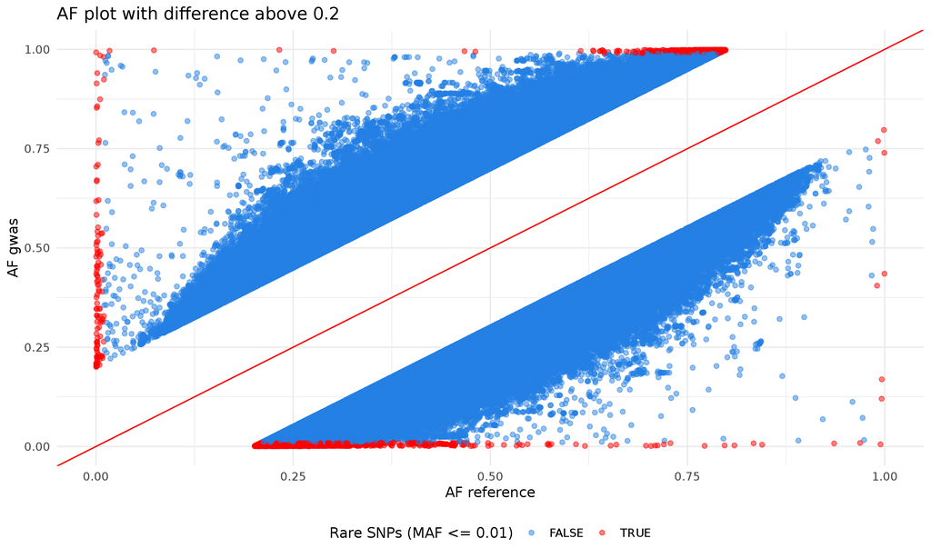

af_plot

### P-Z plot

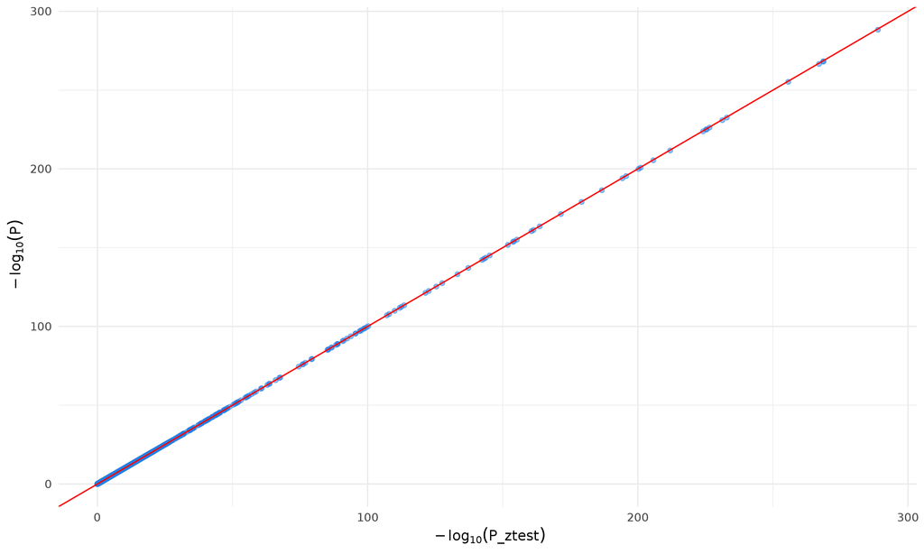

pz_plot

### beta_std plot

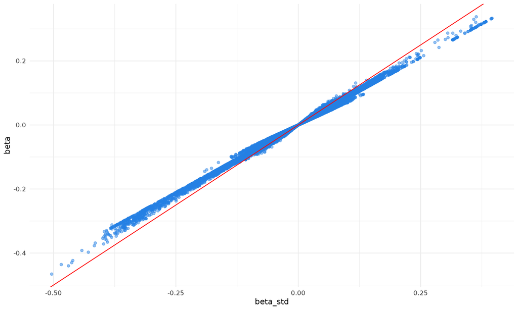

beta_std_plot

### Metadata

[output not shown]

### LDSC

```
*********************************************************************
* LD Score Regression (LDSC)
* Version 1.0.1
* (C) 2014-2019 Brendan Bulik-Sullivan and Hilary Finucane
* Broad Institute of MIT and Harvard / MIT Department of Mathematics
* GNU General Public License v3
*********************************************************************
Call:
./ldsc.py \
--h2 /mnt/storage/private/mrcieu/research/scratch/IGD/data/dev/ukb-d-import/processed/ukb-d-30880_irnt/ukb-d-30880_irnt.vcf.gz \
--ref-ld-chr /mnt/storage/private/mrcieu/research/scratch/IGD/data/dev/reference/eur_w_ld_chr/ \
--out /mnt/storage/private/mrcieu/research/scratch/IGD/data/dev/ukb-d-import/processed/ukb-d-30880_irnt/ldsc.txt \
--w-ld-chr /mnt/storage/private/mrcieu/research/scratch/IGD/data/dev/reference/eur_w_ld_chr/

Beginning analysis at Mon Nov 25 14:56:07 2019
Reading summary statistics from /mnt/storage/private/mrcieu/research/scratch/IGD/data/dev/ukb-d-import/processed/ukb-d-30880_irnt/ukb-d-30880_irnt.vcf.gz ...
Read summary statistics for 13585993 SNPs.
Dropped 12709 SNPs with duplicated rs numbers.
Reading reference panel LD Score from /mnt/storage/private/mrcieu/research/scratch/IGD/data/dev/reference/eur_w_ld_chr/[1-22] ...
Read reference panel LD Scores for 1290028 SNPs.
Removing partitioned LD Scores with zero variance.
Reading regression weight LD Score from /mnt/storage/private/mrcieu/research/scratch/IGD/data/dev/reference/eur_w_ld_chr/[1-22] ...
Read regression weight LD Scores for 1290028 SNPs.
After merging with reference panel LD, 1283504 SNPs remain.
After merging with regression SNP LD, 1283504 SNPs remain.
Using two-step estimator with cutoff at 30.
Total Observed scale h2: 0.2039 (0.0492)
Lambda GC: 1.6312
Mean Chi^2: 3.7104
Intercept: 1.12 (0.0156)
Ratio: 0.0443 (0.0058)
Analysis finished at Mon Nov 25 14:58:23 2019
Total time elapsed: 2.0m:15.94s
```

# QC metrics

## Metrics

### Metrics

```
{
    "af_correlation": 0.9521,
    "inflation_factor": 1.3819,
    "mean_EFFECT": -2.3439e-06,
    "n": 343836,
    "n_snps": 13585993,
    "n_clumped_hits": 256,
    "n_p_sig": 50138,
    "n_mono": 0,
    "n_ns": 1251781,
    "n_mac": 0,
    "is_snpid_unique": false,
    "n_miss_EFFECT": 0,
    "n_miss_SE": 0,
    "n_miss_PVAL": 0,
    "n_miss_AF": 0,
    "n_miss_AF_reference": 569154,
    "n_est": 345181.7796,
    "ratio_se_n": 1.002,
    "mean_diff": 2.5164e-07,
    "ratio_diff": 0.3734,
    "sd_y_est1": 0.8457,
    "sd_y_est2": 0.8473,
    "r2_sum1": 0.0585,
    "r2_sum2": 0.0818,
    "r2_sum3": 0.0815,
    "r2_sum4": 0.081,
    "ldsc_nsnp_merge_refpanel_ld": 1283504,
    "ldsc_nsnp_merge_regression_ld": 1283504,
    "ldsc_observed_scale_h2_beta": 0.2039,
    "ldsc_observed_scale_h2_se": 0.0492,
    "ldsc_intercept_beta": 1.12,
    "ldsc_intercept_se": 0.0156,
    "ldsc_lambda_gc": 1.6312,
    "ldsc_mean_chisq": 3.7104,
    "ldsc_ratio": 0.0443
}
```

### Flags

| name | value |
| --- | --- |
| af_correlation | FALSE |
| inflation_factor | TRUE |
| n | FALSE |
| is_snpid_non_unique | TRUE |
| mean_EFFECT_nonfinite | FALSE |
| mean_EFFECT_05 | FALSE |
| mean_EFFECT_01 | FALSE |
| mean_chisq | TRUE |
| n_p_sig | TRUE |
| miss_EFFECT | FALSE |
| miss_SE | FALSE |
| miss_PVAL | FALSE |
| ldsc_ratio | FALSE |
| ldsc_intercept_beta | FALSE |
| n_clumped_hits | FALSE |
| r2_sum1 | FALSE |
| r2_sum2 | FALSE |
| r2_sum3 | FALSE |
| r2_sum4 | FALSE |

### Definitions

**General metrics**

- `af_correlation`: Correlation coefficient between `AF` and `AF_reference`.
- `inflation_factor` (`lambda`): Genomic inflation factor.
- `mean_EFFECT`: Mean of `EFFECT` size.
- `n`: Maximum value of reported sample size across all SNPs, $n$.
- `n_clumped_hits`: Number of clumped hits.
- `n_snps`: Number of SNPs
- `n_p_sig`: Number of SNPs with pvalue below `5e-8`.
- `n_mono`: Number of monomorphic (`MAF == 1` or `MAF == 0`) SNPs.
- `n_ns`: Number of SNPs with nonsense values:
  - alleles other than `A, C, G or T`.
  - P-values `< 0` or `> 1`.
  - negative or infinite standard errors (`<= 0` or `= Infinity`).
  - infinite beta estimates or allele frequencies `< 0` or `> 1`.
- `n_mac`: Number of cases where `MAC` ($2 \times N \times MAF$) is less than `6`.
- `is_snpid_unique`: `true` if the combination of `ID` `REF` `ALT` is unique and therefore no duplication in snpid.
- `n_miss_<*>`: Number of `NA` observations for `<*>` column.

**se_n metrics**

- `n_est`: Estimated sample size value, $\widehat{n}$.
- `ratio_se_n`: $\texttt{ratio_se_n} = \frac{\sqrt{\widehat{n}}}{\sqrt{n}}$. We expect `ratio_se_n` to be 1. When it is not 1, it implies that the trait did not have a variance of 1, the reported sample size is wrong, or that the SNP-level effective sample sizes differ markedly from the reported sample size.
- `mean_diff`: $\texttt{mean_diff} = \sum_{j} \frac{\widehat{\beta_j^{std}} - \beta_j}{\texttt{n_snps}}$, mean difference between the standardised beta, predicted from P-values, and the observed beta. The difference should be very close to zero if trait has a variance of 1.
  - $\widehat{\beta_j^{std}} = \sqrt{\frac{{z}_j^2 / ({z}_j^2 + n -2)}{2 \times {MAF}_j \times (1 - {MAF}_j)}} \times sign({z}_j)$,
  - ${z}_j = \frac{\beta_j}{{se}_j}$,
  - and $\beta_j$ is the reported effect size.
- `ratio_diff`: $\texttt{ratio_diff} = |\frac{\texttt{mean_diff}}{\texttt{mean_diff2}}|$, absolute ratio between the mean of `diff` and the mean of `diff2` (expected difference between the standardised beta predicted from P-values, and the standardised beta derived from the observed beta divided by the predicted SD; **NOT** reported). The ratio should be close to 1. If different from 1, then implies that the betas are not in a standard deviation scale.
  - $\texttt{mean_diff2} = \sum_{j} \frac{\widehat{\beta_j^{std}} - \beta^{\prime}_j}{\texttt{n_snps}}$
  - $\beta^{\prime}_j = \frac{\beta_j}{\widehat{\texttt{sd2}}_{y}}$
- `sd_y_est1`: The standard deviation for the trait inferred from the reported sample size, median standard errors for the SNP-trait assocations and SNP variances.
  - $\widehat{\texttt{sd1}}_{y} = \frac{\sqrt{n} \times median({se}_j)}{C}$,
  - $C = median(\frac{1}{\sqrt{2 \times {MAF}_j \times (1 - {MAF}_j)}})$,
  - and ${se}_j$ is the reported standard error.
- `sd_y_est2`: The standard deviation for the trait inferred from the reported sample size, Z statistics for the SNP-trait effects (beta/se) and allele frequency.
  - $\widehat{\texttt{sd2}}_{y} = median(\widehat{sd_j})$,
  - $\widehat{sd_j} = \frac{\beta_j}{\widehat{\beta_j^{std}}}$,

**r2 metrics**

> Sum of variance explained, calculated from the clumped top hits sample.
- `r2_sum<*>`: `r2` statistics under various assumptions
  - `1`: $r^2 = \sum_j{\frac{2 \times \beta_j^2 \times {MAF}_j \times (1 - {MAF}_j)}{\texttt{var1}}}$, $\texttt{var1} = 1$.
  - `2`: $r^2 = \sum_j{\frac{2 \times \beta_j^2 \times {MAF}_j \times (1 - {MAF}_j)}{\texttt{var2}}}$, $\texttt{var2} = {\widehat{\texttt{sd1}}_{y}}^2$,
  - `3`: $r^2 = \sum_j{\frac{2 \times \beta_j^2 \times {MAF}_j \times (1 - {MAF}_j)}{\texttt{var3}}}$, $\texttt{var3} = {\widehat{\texttt{sd2}}_{y}}^2$,
  - `4`: $r^2 = \sum_j{\frac{F_j}{F_j + n - 2}}$, $F = \frac{\beta_j^2}{{se}_j^2}$.

**LDSC metrics**

> Metrics from LD regression
- `ldsc_nsnp_merge_refpanel_ld`: Number of remaining SNPs after merging with reference panel LD.
- `ldsc_nsnp_merge_regression_ld`: Number of remaining SNPs after merging with regression SNP LD.
- `ldsc_observed_scale_h2_{beta,se}` Coefficient value and SE for total observed scale h2.
- `ldsc_intercept_{beta,se}`: Coefficient value and SE for intercept. Intercept is expected to be 1.
- `ldsc_lambda_gc`: Lambda GC statistics.
- `ldsc_mean_chisq`: Mean $\chi^2$ statistics.
- `ldsc_ratio`: $\frac{\texttt{ldsc_intercept_beta} - 1}{\texttt{ldsc_mean_chisq} - 1}$, the proportion of the inflation in the mean $\chi^2$ that the LD Score regression intercepts ascribes to causes other than polygenic heritability. The value of ratio should be close to zero, though in practice values of 0.1-0.2 are not uncommon, probably due to sample/reference LD Score mismatch or model misspecification (e.g., low LD variants have slightly higher $h^2$ per SNP).

**Flags**

> When a metric needs attention, the flag should return TRUE.
- `af_correlation`: `abs(af_correlation)` < 0.7.
- `inflation_factor`: `inflation_factor` > 1.2.
- `n`: `n` (max reported sample size) < 10000.
- `is_snpid_non_unique`: NOT `is_snpid_unique`.
- `mean_EFFECT_nonfinite`: `mean(EFFECT)` is `NA`, `NaN`, or `Inf`.
- `mean_EFFECT_05`: `abs(mean(EFFECT))` > 0.5.
- `mean_EFFECT_01`: `abs(mean(EFFECT))` > 0.1.
- `mean_chisq`: `ldsc_mean_chisq` > 1.3 or `ldsc_mean_chisq` < 0.7.
- `n_p_sig`: `n_p_sig` > 1000.
- `miss_<*>`: `n_miss_<*>` / `n_snps` > 0.01.
- `ldsc_ratio`: `ldsc_ratio` > 0.5
- `ldsc_intercept_beta`: `ldsc_intercept_beta` > 1.5
- `n_clumped_hits`: `n_clumped_hits` > 1000
- `r2_sum<*>`: `r2_sum<*>` > 0.5

**Plots**

- Manhattan plot
  - Red line: $-log_{10}^{5 \times 10^{-8}}$
  - Blue line: $-log_{10}^{5 \times 10^{-5}}$
- QQ plot
- AF plot
- P-Z plot
- beta_std plot: Scatter plot between $\widehat{\beta_j^{std}}$ and $\beta_j$

# Diagnostics

## Details

### Summary stats

| skim_type | skim_variable | n_missing | complete_rate | character.min | character.max | character.empty | character.n_unique | character.whitespace | numeric.mean | numeric.sd | numeric.p0 | numeric.p25 | numeric.p50 | numeric.p75 | numeric.p100 | numeric.hist |
| --- | --- | --- | --- | --- | --- | --- | --- | --- | --- | --- | --- | --- | --- | --- | --- | --- |
| character | ID | 0 | 1.0000000 | 3 | 94 | 0 | 13573948 | 0 | NA | NA | NA | NA | NA | NA | NA | NA |
| character | REF | 0 | 1.0000000 | 1 | 100 | 0 | 57080 | 0 | NA | NA | NA | NA | NA | NA | NA | NA |
| character | ALT | 0 | 1.0000000 | 1 | 342 | 0 | 33337 | 0 | NA | NA | NA | NA | NA | NA | NA | NA |
| numeric | CHROM | 0 | 1.0000000 | NA | NA | NA | NA | NA | 9.051238e+00 | 6.184962e+00 | 1.00000e+00 | 4.000000e+00 | 8.000000e+00 | 1.300000e+01 | 2.300000e+01 | ▇▅▅▂▂ |
| numeric | POS | 0 | 1.0000000 | NA | NA | NA | NA | NA | 7.902571e+07 | 5.591523e+07 | 3.02000e+02 | 3.293111e+07 | 7.013925e+07 | 1.148602e+08 | 2.492309e+08 | ▇▆▅▂▁ |
| numeric | EFFECT | 0 | 1.0000000 | NA | NA | NA | NA | NA | -2.300000e-06 | 1.298030e-02 | -4.65770e-01 | -3.888300e-03 | 1.300000e-06 | 3.892400e-03 | 3.379000e-01 | ▁▁▇▁▁ |
| numeric | SE | 0 | 1.0000000 | NA | NA | NA | NA | NA | 8.569600e-03 | 8.266300e-03 | 1.67660e-03 | 2.439900e-03 | 4.496000e-03 | 1.231500e-02 | 4.178200e-02 | ▇▂▁▁▁ |
| numeric | PVAL | 0 | 1.0000000 | NA | NA | NA | NA | NA | 4.465692e-01 | 3.036434e-01 | 0.00000e+00 | 1.701300e-01 | 4.278396e-01 | 7.097608e-01 | 1.000000e+00 | ▇▆▅▅▅ |
| numeric | PVAL_ztest | 0 | 1.0000000 | NA | NA | NA | NA | NA | 4.465687e-01 | 3.036436e-01 | 0.00000e+00 | 1.701301e-01 | 4.278420e-01 | 7.097564e-01 | 9.999998e-01 | ▇▆▅▅▅ |
| numeric | AF | 0 | 1.0000000 | NA | NA | NA | NA | NA | 1.908099e-01 | 2.544045e-01 | 1.00000e-03 | 7.431500e-03 | 6.004100e-02 | 2.953200e-01 | 9.989990e-01 | ▇▂▁▁▁ |
| numeric | AF_reference | 569154 | 0.9581073 | NA | NA | NA | NA | NA | 1.963392e-01 | 2.471027e-01 | 0.00000e+00 | 5.591000e-03 | 8.426520e-02 | 3.081070e-01 | 1.000000e+00 | ▇▂▁▁▁ |
| numeric | N | 0 | 1.0000000 | NA | NA | NA | NA | NA | 3.438360e+05 | 0.000000e+00 | 3.43836e+05 | 3.438360e+05 | 3.438360e+05 | 3.438360e+05 | 3.438360e+05 | ▁▁▇▁▁ |

### Head and tail

[output not shown]

| CHROM | POS | ID | REF | ALT | EFFECT | SE | PVAL | PVAL_ztest | AF | AF_reference | N |
| --- | --- | --- | --- | --- | --- | --- | --- | --- | --- | --- | --- |
| 23 | 154923311 | rs141127553 | C | T | 0.0017117 | 0.0036969 | 0.6433495 | 0.6433575 | 0.056204 | 0.0309934 | 343836 |
| 23 | 154923374 | rs111332691 | T | A | 0.0089624 | 0.0040583 | 0.0272157 | 0.0272155 | 0.044880 | 0.0116556 | 343836 |
| 23 | 154925045 | rs509981 | C | T | 0.0012802 | 0.0019549 | 0.5125603 | 0.5125532 | 0.245700 | 0.3634440 | 343836 |
| 23 | 154925895 | rs538470 | C | T | 0.0011665 | 0.0019998 | 0.5596700 | 0.5596858 | 0.242030 | 0.3634440 | 343836 |
| 23 | 154927581 | rs644138 | G | A | 0.0015711 | 0.0018386 | 0.3928204 | 0.3928231 | 0.302290 | 0.4635760 | 343836 |
| 23 | 154929412 | rs557132 | C | T | 0.0012743 | 0.0019555 | 0.5146204 | 0.5146275 | 0.245560 | 0.3568210 | 343836 |
| 23 | 154929637 | rs35185538 | CT | C | 0.0007136 | 0.0020409 | 0.7266194 | 0.7266163 | 0.229820 | 0.3011920 | 343836 |
| 23 | 154929952 | rs4012982 | CAA | C | 0.0009065 | 0.0020566 | 0.6593606 | 0.6593611 | 0.239530 | 0.3165560 | 343836 |
| 23 | 154930230 | rs781880 | A | G | 0.0013977 | 0.0019552 | 0.4746997 | 0.4746937 | 0.245960 | 0.3618540 | 343836 |
| 23 | 154930487 | rs781879 | T | A | 0.0056700 | 0.0067020 | 0.3975402 | 0.3975438 | 0.019564 | 0.1263580 | 343836 |

### bcf preview

```
1   692794  rs530212009 CA  C   .   PASS    AF=0.11052  ES:SE:LP:AF:SS:ID   -0.0027613:0.0035721:0.357031:0.11052:343836:1_692794_CA_C
1   693731  rs12238997  A   G   .   PASS    AF=0.11581  ES:SE:LP:AF:SS:ID   -0.0011528:0.0033737:0.135145:0.11581:343836:rs12238997
1   707522  rs371890604 G   C   .   PASS    AF=0.097254 ES:SE:LP:AF:SS:ID   0.0015503:0.0037946:0.165662:0.097254:343836:rs371890604
1   717587  rs144155419 G   A   .   PASS    AF=0.015662 ES:SE:LP:AF:SS:ID   -0.012499:0.0090588:0.775571:0.015662:343836:rs144155419
1   723329  rs189787166 A   T   .   PASS    AF=0.0017349    ES:SE:LP:AF:SS:ID   -0.0092025:0.026696:0.136493:0.0017349:343836:rs189787166
1   730087  rs148120343 T   C   .   PASS    AF=0.056426 ES:SE:LP:AF:SS:ID   -0.0046803:0.0047018:0.495502:0.056426:343836:rs148120343
1   731718  rs58276399  T   C   .   PASS    AF=0.1217   ES:SE:LP:AF:SS:ID   -0.0011052:0.0031998:0.136796:0.1217:343836:rs58276399
1   732032  rs61770163  A   C   .   PASS    AF=0.1211   ES:SE:LP:AF:SS:ID   8.4753e-05:0.0034144:0.0086853:0.1211:343836:rs61770163
1   734349  rs141242758 T   C   .   PASS    AF=0.12092  ES:SE:LP:AF:SS:ID   -0.0009744:0.0032015:0.118701:0.12092:343836:rs141242758
1   740284  rs61770167  C   T   .   PASS    AF=0.0057564    ES:SE:LP:AF:SS:ID   0.022663:0.014685:0.910943:0.0057564:343836:rs61770167
1   742813  rs112573343 C   T   .   PASS    AF=0.0018612    ES:SE:LP:AF:SS:ID   0.031602:0.027841:0.591184:0.0018612:343836:rs112573343
1   749963  rs529266287 T   TAA .   PASS    AF=0.8698   ES:SE:LP:AF:SS:ID   7.3576e-05:0.0031563:0.00815395:0.8698:343836:rs529266287
1   750230  rs190826124 G   C   .   PASS    AF=0.0015221    ES:SE:LP:AF:SS:ID   0.014289:0.028665:0.20892:0.0015221:343836:rs190826124
1   751343  rs28544273  T   A   .   PASS    AF=0.12288  ES:SE:LP:AF:SS:ID   -0.00048069:0.0031257:0.0566143:0.12288:343836:rs28544273
1   751488  rs200141114 G   GA  .   PASS    AF=0.14268  ES:SE:LP:AF:SS:ID   -0.00094091:0.0030892:0.118792:0.14268:343836:rs200141114
1   751756  rs28527770  T   C   .   PASS    AF=0.12299  ES:SE:LP:AF:SS:ID   -0.0003919:0.0031213:0.0457189:0.12299:343836:rs28527770
1   753405  rs3115860   C   A   .   PASS    AF=0.87096  ES:SE:LP:AF:SS:ID   0.00011129:0.0030421:0.0128613:0.87096:343836:rs3115860
1   753425  rs3131970   T   C   .   PASS    AF=0.87552  ES:SE:LP:AF:SS:ID   -0.00026757:0.0030922:0.0310317:0.87552:343836:rs3131970
1   753541  rs2073813   G   A   .   PASS    AF=0.12857  ES:SE:LP:AF:SS:ID   -0.00052171:0.0030496:0.0634058:0.12857:343836:rs2073813
1   754105  rs12184325  C   T   .   PASS    AF=0.036315 ES:SE:LP:AF:SS:ID   0.0018198:0.005537:0.129356:0.036315:343836:rs12184325
1   754182  rs3131969   A   G   .   PASS    AF=0.87056  ES:SE:LP:AF:SS:ID   0.00026666:0.0030389:0.0314797:0.87056:343836:rs3131969
1   754192  rs3131968   A   G   .   PASS    AF=0.87066  ES:SE:LP:AF:SS:ID   0.0001848:0.0030403:0.0215775:0.87066:343836:rs3131968
1   754334  rs3131967   T   C   .   PASS    AF=0.87055  ES:SE:LP:AF:SS:ID   0.00029785:0.0030388:0.0353068:0.87055:343836:rs3131967
1   754433  rs150578204 G   A   .   PASS    AF=0.0050494    ES:SE:LP:AF:SS:ID   0.0073141:0.015586:0.194581:0.0050494:343836:rs150578204
1   754458  rs142682604 G   T   .   PASS    AF=0.0050163    ES:SE:LP:AF:SS:ID   0.0072602:0.015628:0.192303:0.0050163:343836:rs142682604
1   755435  rs184270342 T   G   .   PASS    AF=0.0055482    ES:SE:LP:AF:SS:ID   0.012214:0.015165:0.376151:0.0055482:343836:rs184270342
1   755890  rs3115858   A   T   .   PASS    AF=0.87064  ES:SE:LP:AF:SS:ID   -7.2196e-06:0.0030336:0.000825944:0.87064:343836:rs3115858
1   756434  rs61768170  G   C   .   PASS    AF=0.12592  ES:SE:LP:AF:SS:ID   0.00026131:0.0030952:0.0302487:0.12592:343836:rs61768170
1   756604  rs3131962   A   G   .   PASS    AF=0.87021  ES:SE:LP:AF:SS:ID   -0.0002663:0.0030264:0.0315731:0.87021:343836:rs3131962
1   757640  rs3115853   G   A   .   PASS    AF=0.86949  ES:SE:LP:AF:SS:ID   -7.2308e-05:0.0030236:0.00836641:0.86949:343836:rs3115853
1   757734  rs4951929   C   T   .   PASS    AF=0.87036  ES:SE:LP:AF:SS:ID   -6.0395e-05:0.0030289:0.00696518:0.87036:343836:rs4951929
1   757936  rs4951862   C   A   .   PASS    AF=0.87036  ES:SE:LP:AF:SS:ID   -6.5333e-05:0.0030291:0.00753927:0.87036:343836:rs4951862
1   758144  rs3131956   A   G   .   PASS    AF=0.87037  ES:SE:LP:AF:SS:ID   -2.109e-05:0.0030292:0.00242142:0.87037:343836:rs3131956
1   758626  rs3131954   C   T   .   PASS    AF=0.87081  ES:SE:LP:AF:SS:ID   2.3955e-05:0.0030369:0.00274034:0.87081:343836:rs3131954
1   759293  rs10157329  T   A   .   PASS    AF=0.098797 ES:SE:LP:AF:SS:ID   -0.00063746:0.0035295:0.0671864:0.098797:343836:rs10157329
1   759600  rs545998451 AGT A   .   PASS    AF=0.006435 ES:SE:LP:AF:SS:ID   0.014226:0.0137:0.524213:0.006435:343836:1_759600_AGT_A
1   759837  rs3115851   T   A   .   PASS    AF=0.8747   ES:SE:LP:AF:SS:ID   0.00032377:0.0030819:0.0379481:0.8747:343836:rs3115851
1   761732  rs2286139   C   T   .   PASS    AF=0.86411  ES:SE:LP:AF:SS:ID   0.00056182:0.0030229:0.069275:0.86411:343836:rs2286139
1   761752  rs1057213   C   T   .   PASS    AF=0.8695   ES:SE:LP:AF:SS:ID   0.00025174:0.0030517:0.0295322:0.8695:343836:rs1057213
1   762273  rs3115849   G   A   .   PASS    AF=0.86644  ES:SE:LP:AF:SS:ID   0.00064126:0.0030523:0.0790423:0.86644:343836:rs3115849
1   762485  rs12095200  C   A   .   PASS    AF=0.098742 ES:SE:LP:AF:SS:ID   -0.00033827:0.003654:0.0332765:0.098742:343836:rs12095200
1   762589  rs3115848   G   C   .   PASS    AF=0.87161  ES:SE:LP:AF:SS:ID   0.00045496:0.0030872:0.054118:0.87161:343836:rs3115848
1   762592  rs3131950   C   G   .   PASS    AF=0.87161  ES:SE:LP:AF:SS:ID   0.00045506:0.0030872:0.0541328:0.87161:343836:rs3131950
1   762601  rs3131949   T   C   .   PASS    AF=0.87161  ES:SE:LP:AF:SS:ID   0.00045075:0.0030873:0.053587:0.87161:343836:rs3131949
1   762632  rs3131948   T   A   .   PASS    AF=0.87199  ES:SE:LP:AF:SS:ID   0.00019737:0.003089:0.0227109:0.87199:343836:rs3131948
1   764191  rs7515915   T   G   .   PASS    AF=0.12551  ES:SE:LP:AF:SS:ID   -0.00044898:0.0030911:0.0532973:0.12551:343836:rs7515915
1   766007  rs61768174  A   C   .   PASS    AF=0.10539  ES:SE:LP:AF:SS:ID   0.00055939:0.003366:0.0614753:0.10539:343836:rs61768174
1   766105  rs2519015   T   A   .   PASS    AF=0.85547  ES:SE:LP:AF:SS:ID   -0.00017759:0.0030217:0.0208479:0.85547:343836:rs2519015
1   767393  rs538667473 A   C   .   PASS    AF=0.0016536    ES:SE:LP:AF:SS:ID   -0.020044:0.026763:0.34304:0.0016536:343836:rs538667473
1   768116  rs376645387 A   AGTTTT  .   PASS    AF=0.83828  ES:SE:LP:AF:SS:ID   -0.004398:0.0029752:0.855862:0.83828:343836:rs376645387
```